# Data Exploration

### YearsAtCompany:

- Number of years at company.
- Numerical (Discrete).
- Not normally distributed, appears to skew to the right.

```
dtype:  int64
Mean:   7.008
Median: 5.0
Mode:   5
STD:    6.127
Min:    0.000
25%:    3.000
50%:    5.000
75%:    9.000
Max:    40.000
Skew:   1.765
```

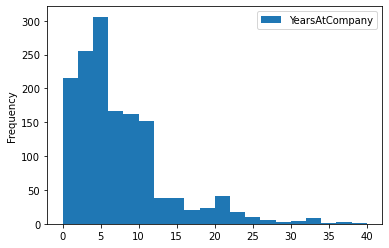

```python
numericalStatsGraphs(['YearsAtCompany'])
```

### YearsInCurrentRole:

- Number of years in current role.
- Numerical (Discrete).
- Not normally distributed, appears to skew to the right.

```
dtype:  int64
Mean:   4.229
Median: 3.0
Mode:   2
STD:    3.623
Min:    0.000
25%:    2.000
50%:    3.000
75%:    7.000
Max:    18.000
Skew:   0.917
```

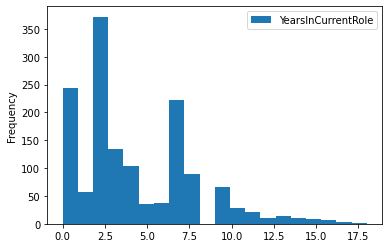

```python
numericalStatsGraphs(['YearsInCurrentRole'])
```

### YearsSinceLastPromotion:

- Number of years since last promotion.
- Numerical (Discrete).
- Not normally distributed, appears to skew to the right.

```
dtype:  int64
Mean:   2.188
Median: 1.0
Mode:   0
STD:    3.222
Min:    0.000
25%:    0.000
50%:    1.000
75%:    3.000
Max:    15.000
Skew:   1.984
```

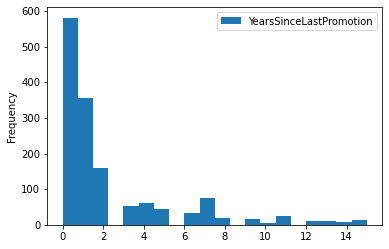

```python
numericalStatsGraphs(['YearsSinceLastPromotion'])
```

### YearsWithCurrManager:

- Number of years with current manager.
- Numerical (Discrete).
- Not normally distributed, appears to skew to the right.

```
dtype:  int64
Mean:   4.123
Median: 3.0
Mode:   2
STD:    3.568
Min:    0.000
25%:    2.000
50%:    3.000
75%:    7.000
Max:    17.000
Skew:   0.833
```

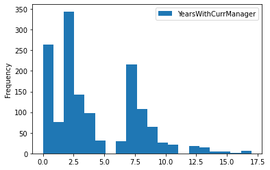

```python
numericalStatsGraphs(['YearsWithCurrManager'])
```

## Correlation Matrix

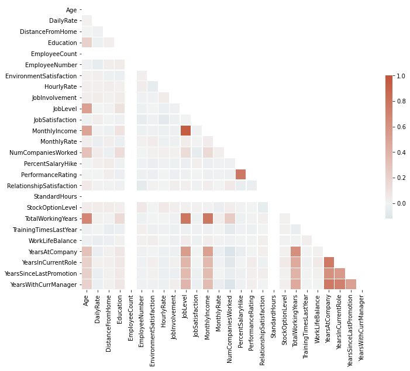

```python
dataframe_corr = correlationMatrix(hr_employee_attrition)
```

### Top Correlations

```python
sorted_pairs = dataframe_corr.unstack().sort_values(kind="quicksort")
abs_sorted_pairs = sorted_pairs[abs(sorted_pairs) >= 0.7  ].head(14)
abs_sorted_pairs
```

```
YearsWithCurrManager  YearsInCurrentRole      0.714365
YearsInCurrentRole    YearsWithCurrManager    0.714365
YearsAtCompany        YearsInCurrentRole      0.758754
YearsInCurrentRole    YearsAtCompany          0.758754
YearsWithCurrManager  YearsAtCompany          0.769212
YearsAtCompany        YearsWithCurrManager    0.769212
MonthlyIncome         TotalWorkingYears       0.772893
TotalWorkingYears     MonthlyIncome           0.772893
PercentSalaryHike     PerformanceRating       0.773550
PerformanceRating     PercentSalaryHike       0.773550
TotalWorkingYears     JobLevel                0.782208
JobLevel              TotalWorkingYears       0.782208
                      MonthlyIncome           0.950300
MonthlyIncome         JobLevel                0.950300
dtype: float64
```